# NavHealth Analysis

Tommy Morrison

My approach to advising the direction of heart failure patients towards lower costs and utilization used both the CMS NPI aggregate and full files. From the former, I used charge, service, and beneficiary variables to calculate metrics comparable across providers. Plotting a matrix of those metrics against the HCC Risk Score for each provider patient population allows comparison of each provider simultaneously on each metric while accounting for the expected cost of the patient population.

With the full file, I identified the three most common services performed by each provider and compared how much each provider charged for those services. The large discrepancy in charges between services that account for about one third of total spending in this sample reveals an area of focus for reducing costs. This is the area which I recommend the ACO look to reduce costs: by directing patients towards providers who charge less for these most common services, for which there is a clear pattern.

One important assumption I made in this analysis was on which variable to use as a cost measure. I decided to use the “submitted charges” measure from both datasets. I chose this over the three Medicare payment measures (allowed, paid, standardized) because I saw in the disagreggated file that the Medicare payment measures were almost the same for each service across providers. My research did not lead me to a conclusive answer as to which measure best represented the ACO’s costs, so I chose the variable that allowed for the most interpretation. This analysis could be improved greatly with data on services performed by patient health condition and demographic. As it is, the patient population data cannot provide insight into the cost and utilization problem because it is not possible to attribute any portion of the population to any specific spending or utilization.

## Methodology

```r
library(ggplot2)
library(tidyr)
library(data.table)
library(knitr)
library(DT)
library(zipcode)
library(ggmap)
library(plotly)
library(ggthemes)
library(Cairo)
library(scales)
```

### Medicare Fee-For-Service Provider Utilization & Payment Data, Physician and Other Supplier, Aggregate File

Getting initial data from the CMS website

```r
dat <- read.csv('data.csv', stringsAsFactors=F)
setDT(dat)

data(zipcode)                              #Get zipcode geodata to merge with zips from CMS data
setDT(zipcode)
zipcode <- zipcode[state=='KY']

setnames(dat, "Zip.Code.of.the.Provider", 'zipcode')
setnames(dat, 'City.of.the.Provider', 'city')
gsub('.{3}$', '', dat$zipcode)
dat$zipcode <- sub("^(\\d{5}).*$", "\\1", dat$zipcode)
dat <- merge(zipcode,
             dat,
             by.x='zip',
             by.y='zipcode')
setnames(dat, 'Last.Name.Organization.Name.of.the.Provider','Organization')

BG <- geocode('Bowling Green, KY')         #Get the coordinates for Bowling Green, KY with `ggmap` package function
BG$city <- 'Bowling Green'
mapData <- setDT(map_data('county'))       #Get Kentucky county lines
mapData <- mapData[region=='kentucky']
```

Map the cardiologists by zip code in the entire state

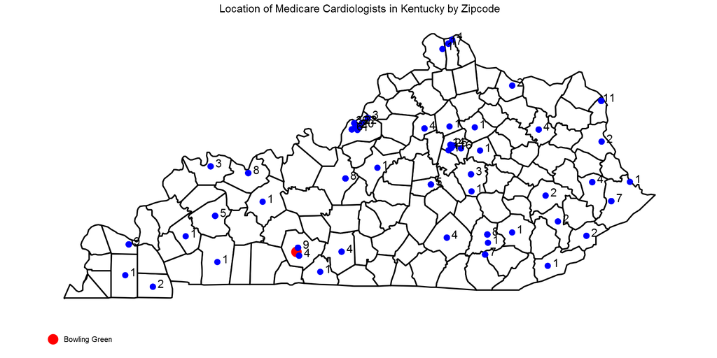

```r
ggplot() +
  geom_polygon(data=mapData, aes(x=long, y=lat, group=group), fill="white", color='black') +
  geom_point(data=BG, aes(x=lon, y=lat, col=city), size=4) +
  geom_point(data=dat[Provider.Type.of.the.Provider=='Cardiology'], aes(x=longitude,y=latitude), col='blue',  size=2) +
  geom_text(data=dat[Provider.Type.of.the.Provider=='Cardiology', .N, by=.(zip, latitude, longitude)], aes(x=longitude, y=latitude, label=N), nudge_x=.1, nudge_y=.03) +
  coord_map() +  scale_color_manual(name=NULL, values='red') +
  ggtitle('Location of Medicare Cardiologists in Kentucky by Zipcode') +
  theme_map() +  theme(legend.position='bottom') +  theme(plot.title = element_text(hjust = 0.5))
```

Subset the data for the Bowling Green area and cardiologists

```r
dat2 <- dat[city.x %in% c('Glasgow', 'Scottsville', 'Bowling Green') & Provider.Type.of.the.Provider=='Cardiology']
```

#### HCC Risk Score

```r
int <- dat2[,c('Total.Submitted.Charge.Amount',"Number.of.Services",'Average.HCC.Risk.Score.of.Beneficiaries','Organization','Number.of.Medicare.Beneficiaries'),with=F]
int[, `Dollars per service`:=Total.Submitted.Charge.Amount/Number.of.Services]
int[, `Dollars per beneficiary` :=Total.Submitted.Charge.Amount/Number.of.Medicare.Beneficiaries]
int[, `Services per beneficiary`:=Number.of.Services/Number.of.Medicare.Beneficiaries]
int <- int[,c(3,4,6,7,8), with=FALSE]
int <- gather(int, Metric, value, -Organization, -Average.HCC.Risk.Score.of.Beneficiaries)
```

```r
g <- ggplot(int, aes(x=Average.HCC.Risk.Score.of.Beneficiaries, y=value)) +
  geom_point(aes(color=Organization)) +
  geom_smooth(method='lm', formula=y~x, se=FALSE) +
  facet_grid(Metric~., scales='free_y') +
  ylab('') + xlab('Avg. HCC Risk Score')

ggplotly(g, tooltip=c('Organization'))
```

[interactive chart not shown]

Viewing the above information in a table that can be filtered:

```r
dat2[, Dollars_per_service := Total.Submitted.Charge.Amount/Number.of.Services]
dat2[, Services_per_patient := Number.of.Services/Number.of.Medicare.Beneficiaries]
dat2[, Dollar_per_patient := Total.Submitted.Charge.Amount/Number.of.Medicare.Beneficiaries]
```

```r
#DT::datatable(dat2[,c(6,7,21,22,25,74,75,77,76),with=FALSE],
DT::datatable(dat2[,c(6,7,21,22,23,74,75,77,76),with=FALSE],
              colnames=c('NPI','Org. Name','Num. of Services','Num. of Medicare Beneficiaries','Total Submitted Charges','Avg. Beneficiary HCC Risk Score','Dollars per Service','Dollars per Beneficiary','Services per Beneficiary')) %>%
  formatCurrency(c(5,7,8), '$', digits=2) %>%
  formatCurrency(c(3,4), '') %>%
  formatCurrency(c(7), '', digits=4) %>%
  formatRound(c(3,4), digits=0) %>%
  formatRound(c(9), digits=1)
```

|  | NPI | Org. Name | Num. of Services | Num. of Medicare Beneficiaries | Total Submitted Charges | Avg. Beneficiary HCC Risk Score | Dollars per Service | Dollars per Beneficiary | Services per Beneficiary |
| --- | --- | --- | --- | --- | --- | --- | --- | --- | --- |
| 1 | 1649258088 | SAHETYA | 17934 | 1412 | 2785989 | 1.581 | 155.346771495483 | 1973.08002832861 | 12.7011331444759 |
| 2 | 1992952501 | DAWSON | 946 | 243 | 345738.75 | 1.5855 | 365.474365750529 | 1422.79320987654 | 3.89300411522634 |
| 3 | 1821124504 | BRUMFIELD | 1446 | 535 | 418829.54 | 1.8421 | 289.646984785615 | 782.858953271028 | 2.70280373831776 |
| 4 | 1487826814 | ROY | 16 | 16 | 1200 | 1.4761 | 75 | 75 | 1 |
| 5 | 1932304813 | WAKED | 4883 | 582 | 1456383 | 1.6894 | 298.255785377842 | 2502.37628865979 | 8.39003436426117 |
| 6 | 1053310409 | KAZIMUDDIN | 4939 | 1258 | 2012402.39 | 1.5041 | 407.451384895728 | 1599.68393481717 | 3.92607313195548 |
| 7 | 1730185166 | PRIBBLE | 4253 | 751 | 490416 | 1.5675 | 115.310604279332 | 653.017310252996 | 5.66311584553928 |
| 8 | 1083655047 | EMANUELE | 1647 | 518 | 206509.54 | 1.7906 | 125.385270188221 | 398.667065637066 | 3.17953667953668 |
| 9 | 1205887858 | CHHABRA | 10996 | 1455 | 1628911 | 1.5969 | 148.136686067661 | 1119.5264604811 | 7.5573883161512 |
| 10 | 1437188984 | FITTS | 2934 | 717 | 317963 | 1.3675 | 108.37184730743 | 443.463040446304 | 4.09205020920502 |

[output cut: 8 more lines]

### Medicare Fee-For-Service Provider Utilization & Payment Data, Physician and Other Supplier, Public Use File (full)

```r
upd <- setDT(read.csv('data2.csv', stringsAsFactors=F))
setnames(upd, 'National.Provider.Identifier','NPI')
setnames(upd, 'Last.Name.Organization.Name.of.the.Provider','Name')
setnames(upd, 'City.of.the.Provider','City')
setnames(upd, 'Number.of.Medicare.Beneficiaries','num_beneficiaries')
setnames(upd, 'Number.of.Services','num_services')
setnames(upd,'Number.of.Distinct.Medicare.Beneficiary.Per.Day.Services','num_distinct')
upd[, Services.per.Beneficiary := num_services/num_beneficiaries]
upd_Kentucky <- copy(upd)
upd <- upd[City %in% c('GLASGOW', 'SCOTTSVILLE', 'BOWLING GREEN') & Provider.Type.of.the.Provider=='Cardiology']
```

How many distinct services did each provider provide?

```r
kable(upd[, .N, by=.(Name, HCPCS.Code)][, .N, by=Name][order(-N)], col.names=c('Provider','Unique Services'),align=c('l','l'), caption='Number of Services Provided per Provider')
```

Number of Services Provided per Provider

| Provider | Unique Services |
| --- | --- |
| CHHABRA | 64 |
| SAHETYA | 43 |
| HARRIS | 40 |
| PRIBBLE | 39 |
| KAZIMUDDIN | 36 |
| WAKED | 30 |
| REDDY | 30 |
| DAMODARAN-NAIR | 29 |
| AKBAR | 28 |
| BRYANT | 24 |
| SALIFU | 24 |
| FITTS | 24 |
| BRUMFIELD | 23 |
| HARSTON | 22 |
| DAWSON | 18 |
| EMANUELE | 18 |
| GOTT | 4 |
| ROY | 1 |

Of the 18 providers, one provided only one type of service and another provided only four types of services, whereas the next provided 18 different types of services and up to 64. As this is significantly off the norm, I will exclude these two providers from the rest of the analysis. They are ‘ROY’ and ‘GOTT’.

Which services are performed by the most providers?

```r
kable(head(upd[!(Name %in% c('ROY','GOTT')), .N, by=.(NPI,HCPCS.Code)][, .N, by=HCPCS.Code][order(-N)],10), col.names=c('HCPCS Code','Num. Providers'), align=c('l','l'), caption='Top 10 Services by Number of Providers Who Performed It')
```

Top 10 Services by Number of Providers Who Performed It

| HCPCS Code | Num. Providers |
| --- | --- |
| 99232 | 16 |
| 93306 | 16 |
| 99214 | 16 |
| 93000 | 15 |
| 99204 | 15 |
| 99213 | 15 |
| 93016 | 14 |
| 78452 | 13 |
| 93018 | 13 |
| 99223 | 13 |

Of those remaining 16 providers, all 16 provided three services: HCPCS codes 99232, 93306, & 99214.

Where did they perform those services?

```r
kable(upd2[HCPCS.Code %in% c(99232,93306,99214), .N, by=.(Name,Place.of.Service,HCPCS.Code)][, .N, by=.(HCPCS.Code, Place.of.Service)][order(HCPCS.Code)],align='lll', caption='Number of Providers per Service and Setting')
```

Number of Providers per Service and Setting

| HCPCS.Code | Place.of.Service | N |
| --- | --- | --- |
| 93306 | O | 13 |
| 93306 | F | 16 |
| 99214 | F | 5 |
| 99214 | O | 16 |
| 99232 | F | 16 |

According to the above roll up function, every provider performed HCPCS 93306 and 99232 in a facility setting and HCPCS 99214 in a non-facility setting. This allows us to compare submitted payments across all providers.

For reference:

- 99232: “Subsequent hospital inpatient care, typically 25 minutes per day”
- 99306: “Ultrasound examination of heart including color-depicted blood flow rate, direction, and valve function”
- 99214: “Established patient office or other outpatient, visit typically 25 minutes”

What were the most popular services by total number of distinct beneficiaries?

```r
kable(head(upd2[,sum(num_distinct),by=HCPCS.Code][order(-V1)],5), col.names=c('HCPCS Code', 'Total Distinct Beneficiaries'), align=c('l','l'), caption='Top 5 Services by Number of Distinct Beneficiaries')
```

Top 5 Services by Number of Distinct Beneficiaries

| HCPCS Code | Total Distinct Beneficiaries |
| --- | --- |
| 99214 | 10704 |
| 93306 | 6217 |
| 99232 | 5781 |
| 93010 | 4723 |
| 93000 | 4290 |

The top three services by distinct beneficiary are 99214, 93306, and 99232— the same as the three services which each provider performed.

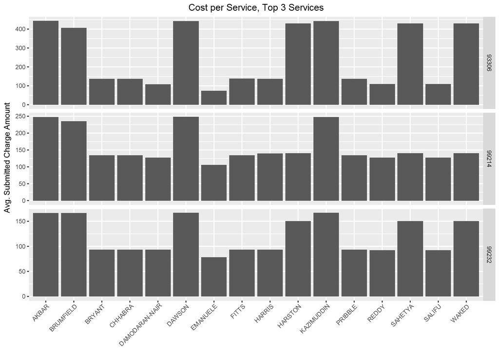

```r
d <- rbind(upd2[HCPCS.Code==99232 & Place.of.Service=='F'],upd2[HCPCS.Code==93306 & Place.of.Service=='F'],upd2[HCPCS.Code==99214 & Place.of.Service=='O'])

#d <- merge(d, dat2[,c('Organization', 'Average.HCC.Risk.Score.of.Beneficiaries'), with=F], by.x='Name',by.y='Organization')
ggplot(d, aes(x=Name, y=Average.Submitted.Charge.Amount)) +
  geom_bar(stat='identity') +
  facet_grid(HCPCS.Code~., scales='free_y') +
  theme(axis.text.x=element_text(angle=45, hjust=1)) +  theme(plot.title=element_text(hjust=.5)) +
  xlab('') + ylab('Avg. Submitted Charge Amount') + ggtitle('Cost per Service, Top 3 Services')
```

What fraction of total costs were those top 3 services responsible for?

```r
#upd2[, sum(num_services * Average.Medicare.Payment.Amount)] #4155241 total services * medicare payment amount
#upd2[, sum(num_services * Average.Submitted.Charge.Amount)] #12898250 total services * submitted charges
d<- merge(head(upd2[, .(`Medicare Payment Share`=sum(num_services * Average.Medicare.Payment.Amount)/4155241), by=HCPCS.Code], 10),
          head(upd2[, .(`Submitted Charge Share`=sum(num_services * Average.Submitted.Charge.Amount)/12898250), by=HCPCS.Code], 10),
          by='HCPCS.Code')[order(-`Submitted Charge Share`)]

kable(d, align='lll', caption='Top Ten Services by Cost Share', digits=round(2))
```

Top Ten Services by Cost Share

| HCPCS.Code | Medicare Payment Share | Submitted Charge Share |
| --- | --- | --- |
| 93306 | 0.11 | 0.16 |
| 99214 | 0.18 | 0.11 |
| 78452 | 0.08 | 0.09 |
| 99232 | 0.07 | 0.05 |
| 92928 | 0.04 | 0.05 |
| A9502 | 0.10 | 0.05 |
| 93000 | 0.01 | 0.02 |
| 93308 | 0.00 | 0.00 |
| Q2037 | 0.00 | 0.00 |
| 93325 | 0.00 | 0.00 |

Of all submitted charges, these three services make up 32.5%. Of Medicare paid amounts, they make up 36.4%.

```r
d <- merge(upd2[Name %in% c('AKBAR','BRUMFIELD','DAWSON','KAZIMUDDIN','HARSTON','SAHETYA','WAKED') & HCPCS.Code %in% c(99232,93306,99214),
                .(`Expensive Providers`=sum(num_distinct)),
                by=HCPCS.Code][order(HCPCS.Code)],
           upd2[HCPCS.Code %in% c(99232,93306,99214),
                .(`All Providers`=sum(num_services)),
                by=HCPCS.Code][order(HCPCS.Code)],
           by='HCPCS.Code')
kable(d, caption='Number of Distinct Beneficiaries per Service', align='lll')
```

Number of Distinct Beneficiaries per Service

[output not shown]